# Computational Precision Medicine - Group Project

Gene-expression biomarkers of immunotherapy response

Author

Group 6

Published

November 24, 2026

# Introduction

This report investigates gene-expression biomarkers of immunotherapy response using the IMvigor210 dataset, which contains RNA-seq data from patients with urothelial cancer treated with anti-PD-L1 therapy. We address four research questions:

**RQ1:** Which genes are differentially expressed between responders and non-responders?

**RQ2:** Are 18-gene T-cell-inflamed GEP associated with treatment response?

**RQ3:** How do PD-1 expression, immune-related gene signatures, and TMB compare in their association with treatment response?

**RQ4:** How might differences in tumor purity influence the expression of immune-related biomarkers and their observed associations with treatment response?

## Setup

### Libraries and data

```r
# Load required packages
library(tidyverse)
library(DESeq2)
library(fgsea)
library(msigdbr)
library(immunedeconv)
library(limma)
library(ggplot2)
library(patchwork)
library(ggrepel)
library(knitr)

# Load data
IMVigor <- readRDS("data/IMvigor210_plain.rds")
clinical <- IMVigor$clinical
counts <- IMVigor$counts
tpm <- IMVigor$tpm
```

### Setup and helper functions

```r
# Define consistent color scheme for response groups
response_colors <- c("NR" = "#4E79A7", "R" = "#E15759")

# Helper function for consistent boxplots
plot_response_boxplot <- function(data, variable, y_label,
                                  test_result = NULL,
                                  label_outliers = FALSE) {
  data <- data |> mutate(Response = BOR)
  p <- ggplot(data, aes(x = Response, y = .data[[variable]], fill = Response)) +
    geom_boxplot(outlier.shape = NA, alpha = 0.7) +
    geom_jitter(width = 0.12, alpha = 0.6, size = 1.5, color = "black") +
    scale_fill_manual(values = response_colors) +
    labs(
      x = "Response class",
      y = y_label,
      fill = "Response"
    ) +
    theme_minimal() +
    theme(legend.position = "None")

  # Add p-value
  if (!is.null(test_result) && !is.null(test_result$p.value)) {
    p <- p + annotate(
      "text",
      x = Inf, y = Inf,
      label = paste0("p = ", signif(test_result$p.value, 3)),
      hjust = 1.1, vjust = 1.5
    )
  }

  # Optionally identify and label outliers
  if (label_outliers) {
      outliers <- data |>
        group_by(Response) |>
        filter(
          .data[[variable]] < quantile(.data[[variable]], 0.25, na.rm = TRUE) -
            1.5 * IQR(.data[[variable]], na.rm = TRUE) |
          .data[[variable]] > quantile(.data[[variable]], 0.75, na.rm = TRUE) +
            1.5 * IQR(.data[[variable]], na.rm = TRUE)
        ) |>
        ungroup()

      p <- p + geom_text_repel(
        data = outliers,
        aes(label = pat_id),
        size = 3,
        max.overlaps = Inf,
        box.padding = 0.4,
        point.padding = 0.3,
        show.legend = FALSE
      )
  }

  return(p)
}

# Helper function for consistent scatter plots with correlation
plot_association <- function(data, x, y, x_label, y_label, cor_test = NULL) {
  p <- ggplot(data, aes(x = .data[[x]], y = .data[[y]])) +
    geom_point(alpha = 0.7) +
    geom_smooth(method = "lm", se = FALSE, color = "#4E79A7") +
    labs(
      x = x_label,
      y = y_label
    ) +
    theme_minimal()

  if (!is.null(cor_test)) {
    rho <- if (!is.null(cor_test$estimate)) unname(cor_test$estimate) else NA
    p <- p + annotate(
      "text",
      x = Inf, y = Inf,
      label = paste0(
        "Spearman rho = ", ifelse(!is.na(rho), round(rho, 2), "NA"),
        "\np = ", ifelse(!is.null(cor_test$p.value), signif(cor_test$p.value, 3), "NA")
      ),
      hjust = 1.1, vjust = 1.3
    )
  }
  return(p)
}

# Helper function for volcano plots
plot_volcano <- function(data, log2fc_col = "log2FoldChange", padj_col = "padj",
                         gene_col = "gene", significant_col = "significant") {
  ggplot(data, aes(x = .data[[log2fc_col]], y = -log10(.data[[padj_col]]),
                   color = .data[[significant_col]])) +
    geom_point(alpha = 0.5) +
    scale_color_manual(values = c("FALSE" = "grey", "TRUE" = "#E15759")) +
    labs(
      title = "Volcano plot of differential expression",
      x = "Log2 fold change (Responder vs Non-responder)",
      y = "-Log10 adjusted p-value"
    ) +
    theme_minimal() +
    theme(legend.position = "none")
}
```

## Data Preparation

```r
# Verify sample alignment between clinical and expression data
if (!all(rownames(clinical) == clinical$pat_id)) {
  stop("Row names of clinical data do not match pat_id")
}
if (!all(rownames(clinical) == clinical$sample_id)) {
  stop("Row names of clinical data do not match sample_id")
}

# Filter clinical data
clinical_filtered <- clinical |>
  filter(sample_id == pat_id) |>
  select(pat_id, BOR, TMB)

# Filter counts and tpm to matching samples
counts_filtered <- as.data.frame(counts) |>
  select(all_of(clinical_filtered$pat_id))

tpm_filtered <- as.data.frame(tpm) |>
  select(all_of(clinical_filtered$pat_id))

# Check for missing values in counts
sum(is.na(counts_filtered))
```

```
[1] 0
```

```r
# Convert to matrices
counts_matrix <- as.matrix(counts_filtered)
tpm_matrix <- as.matrix(tpm_filtered)

# Verify alignment
stopifnot(identical(colnames(counts_matrix), rownames(clinical_filtered)))
stopifnot(identical(colnames(tpm_matrix), rownames(clinical_filtered)))
stopifnot(all(colnames(counts_matrix) == rownames(clinical_filtered)))

# Encode BORas factor for DESeq2
clinical_filtered$BOR <- as.factor(clinical_filtered$BOR)

kable(data.frame(
  Check = c("Number of samples",
            "Expression matrix dimensions (counts)",
            "Expression matrix dimensions (TPM)",
            "TMB missing values"),
  Value = c(nrow(clinical_filtered),
            paste(dim(counts_matrix), collapse = " x "),
            paste(dim(tpm_matrix), collapse = " x "),
            sum(is.na(clinical_filtered$TMB)))
))
```

| Check | Value |
| --- | --- |
| Number of samples | 192 |
| Expression matrix dimensions (counts) | 31087 x 192 |
| Expression matrix dimensions (TPM) | 31087 x 192 |
| TMB missing values | 42 |

```r
kable(cbind(BOR = names(table(clinical_filtered$BOR)),
                   table(clinical_filtered$BOR)),
      row.names = FALSE)
```

| BOR |  |
| --- | --- |
| NR | 167 |
| R | 25 |

## Research Question 1: Differential Expression

**Question:** Which genes are differentially expressed between patients with complete response and patients with progressive disease following anti-PD-L1 treatment?

### Methods

- Prepare and explore the gene-expression data with appropriate filtering and normalization
- Perform differential expression analysis using DESeq2
- Identify significantly differentially expressed genes
- Visualize results using volcano plots
- Investigate biological functions using GSEA

### Differential Expression Analysis

[output not shown]

```r
# Create DESeqDataSet
dds <- DESeqDataSetFromMatrix(
  countData = counts_matrix,
  colData = clinical_filtered,
  design = ~ BOR
)

# Filter genes with very low counts
dds <- dds[rowSums(counts(dds)) >= 10, ]

kable(data.frame(
  Check = "DESeqDataSet dimensions after filtering",
  Value = paste(dim(dds), collapse = " x ")
))

dds <- DESeq(dds)
```

```r
# Extract results
res <- results(dds, alpha = 0.05)
kable(summary(res))
```

[output not shown]

```r
# Convert to dataframe
res_df <- as.data.frame(res) |>
  filter(!is.na(padj)) |>
  rownames_to_column("gene") |>
  mutate(
    significant = padj < 0.05,
    Response = "R"
  ) |>
  arrange(padj)

kable(data.frame(
  Check = c("Significant genes at FDR < 0.05", "Total genes tested"),
  Value = c(sum(res_df$significant), nrow(res_df))
))
```

| Check | Value |
| --- | --- |
| Significant genes at FDR < 0.05 | 445 |
| Total genes tested | 19432 |

### Volcano Plot

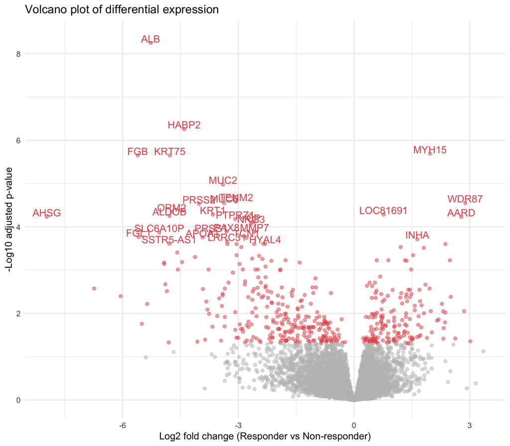

```r
# Get top 30 most significant genes (using all genes with padj, not just significant ones)
top_genes <- res_df |>
  filter(!is.na(padj)) |>
  arrange(padj) |>
  head(30) |>
  pull(gene)

volcano_plot <- plot_volcano(res_df) +
  # Label the top 30 genes
  geom_text(
    data = res_df %>% filter(gene %in% top_genes),
    aes(label = gene),
    size = 4,
    position = position_nudge(y = 0.1)
  )
volcano_plot
```

### Biological Interpretation

Using the top 30 most significantly differentially expressed genes, we can search for their biological functions.

For this, a search for the NCBI Gene database is compiled below. While doing this, it was found that the gene LOC81691 is no longer the preferred symbol for this gene, and has been updated to REXO5. Therefore, we include this in the search query.

The resulting table from NCBI was then exported and imported into R for further analysis.

```r
cat('\nTop 30 significant genes:\n')
```

```
Top 30 significant genes:
```

```r
print(top_genes)
```

```
 [1] "ALB"       "HABP2"     "MYH15"     "FGB"       "KRT75"     "MUC2"
 [7] "TENM2"     "MUC6"      "WDR87"     "PRSS2"     "ORM2"      "KRT1"
[13] "LOC81691"  "ALDOB"     "AHSG"      "AARD"      "PTPRZ1"    "CP"
[19] "NRG3"      "MMP7"      "PAX8"      "PRSS1"     "SLC6A10P"  "FGL1"
[25] "APOA1"     "TCN1"      "INHA"      "LRRC31"    "SSTR5-AS1" "HYAL4"
```

```r
# Load gene annotations for top genes from search
top_genes_annot <- read.csv("data/gene_result.txt", sep = "\t")
kable(top_genes_annot |> select(Symbol, description) |> head(30),
      caption = 'Gene annotations for top genes')
```

Gene annotations for top genes

| Symbol | description |
| --- | --- |
| AARD | alanine and arginine rich domain containing protein |
| AHSG | alpha 2-HS glycoprotein |
| ALB | albumin |
| ALDOB | aldolase, fructose-bisphosphate B |
| APOA1 | apolipoprotein A1 |
| CP | ceruloplasmin |
| FGB | fibrinogen beta chain |
| FGL1 | fibrinogen like 1 |
| HABP2 | hyaluronan binding protein 2 |
| HYAL4 | hyaluronidase 4 |
| INHA | inhibin subunit alpha |
| KRT1 | keratin 1 |
| KRT75 | keratin 75 |
| LRRC31 | leucine rich repeat containing 31 |
| MMP7 | matrix metallopeptidase 7 |
| MUC2 | mucin 2, oligomeric mucus/gel-forming |
| MUC6 | mucin 6, oligomeric mucus/gel-forming (gene/pseudogene) |
| MYH15 | myosin heavy chain 15 |
| NRG3 | neuregulin 3 |
| ORM2 | orosomucoid 2 |
| PAX8 | paired box 8 |
| PRSS1 | serine protease 1 |
| PRSS2 | serine protease 2 |
| PTPRZ1 | protein tyrosine phosphatase receptor type Z1 |
| REXO5 | RNA exonuclease 5 |
| SLC6A10P | solute carrier family 6 member 10, pseudogene |
| SSTR5-AS1 | SSTR5 antisense RNA 1 |
| TCN1 | transcobalamin 1 |
| TENM2 | teneurin transmembrane protein 2 |
| WDR87 | WD repeat domain 87 |

The genes alone are not sufficient for a complete biological interpretation. Additional context and functional annotations are required to understand their role in the biological processes under investigation. Therefore we look into the pathways using Gene Set Enrichment Analysis (GSEA).

### Gene Set Enrichment Analysis (GSEA)

```r
# Prepare ranked genes for GSEA
ranked_genes <- res_df$stat
names(ranked_genes) <- res_df$gene

# Function to run GSEA
gsea <- function(category = "", subcategory = "") {
  if (subcategory != "") {
    gene_sets <- msigdbr(species = "Homo sapiens",
                         collection = category,
                         subcollection = subcategory)
  } else if (category != "") {
    gene_sets <- msigdbr(species = "Homo sapiens",
                         collection = category)
  } else {
    gene_sets <- msigdbr(species = "Homo sapiens")
  }

  split_genes <- split(x = gene_sets$gene_symbol,
                       f = gene_sets$gs_name)

  set.seed(42)
  suppressWarnings({
    fgsea_res <- fgsea(pathways = split_genes,
                       stats = ranked_genes,
                       nproc = 1)
  })

  return(list(fgsea_res = fgsea_res, split_genes = split_genes))
}
```

```r
# Run GSEA for Hallmark, C7, and C8 gene sets
res_H <- gsea(category = "H")
fgsea_H <- res_H$fgsea_res
split_genes_H <- res_H$split_genes

res_C7 <- gsea(category = "C7")
fgsea_C7 <- res_C7$fgsea_res
split_genes_C7 <- res_C7$split_genes

res_C8 <- gsea(category = "C8")
fgsea_C8 <- res_C8$fgsea_res
split_genes_C8 <- res_C8$split_genes
```

```r
# Visualization parameters
number_of_top_pathways_up <- 10
number_of_top_pathways_down <- 10

# Hallmark pathways
topPathwaysUp_H <- fgsea_H[ES > 0][head(order(pval), n = number_of_top_pathways_up), pathway]
topPathwaysDown_H <- fgsea_H[ES < 0][head(order(pval), n = number_of_top_pathways_down), pathway]
topPathways_H <- c(topPathwaysUp_H, rev(topPathwaysDown_H))

# Display pathway enrichment table
if (interactive()) {
  plotGseaTable(split_genes_H[topPathways_H],
                stats = ranked_genes,
                fgseaRes = fgsea_H,
                gseaParam = 0.5)
}

# Get top pathways tables
top_pathways_H <- fgsea_H |>
  dplyr::arrange(padj) |>
  dplyr::slice(1:20)

kable(top_pathways_H |> select(pathway, NES, padj),
      caption = 'Top 20 Hallmark pathways')
```

Top 20 Hallmark pathways

| pathway | NES | padj |
| --- | --- | --- |
| HALLMARK_E2F_TARGETS | 3.685226 | 5.000000e-49 |
| HALLMARK_G2M_CHECKPOINT | 3.151943 | 8.270823e-30 |
| HALLMARK_INTERFERON_GAMMA_RESPONSE | 2.954675 | 1.045519e-24 |
| HALLMARK_MYC_TARGETS_V1 | 2.953810 | 4.303894e-24 |
| HALLMARK_INTERFERON_ALPHA_RESPONSE | 3.016312 | 2.485463e-18 |
| HALLMARK_COAGULATION | -2.731092 | 3.885834e-18 |
| HALLMARK_EPITHELIAL_MESENCHYMAL_TRANSITION | -2.289988 | 3.898363e-12 |
| HALLMARK_DNA_REPAIR | 2.406637 | 1.770694e-11 |
| HALLMARK_HYPOXIA | -2.120268 | 2.641594e-09 |
| HALLMARK_ALLOGRAFT_REJECTION | 2.013369 | 4.602333e-08 |
| HALLMARK_TNFA_SIGNALING_VIA_NFKB | -2.010314 | 1.096017e-07 |
| HALLMARK_MITOTIC_SPINDLE | 1.978227 | 1.607615e-07 |
| HALLMARK_ANGIOGENESIS | -2.289193 | 1.436999e-06 |
| HALLMARK_KRAS_SIGNALING_UP | -1.906732 | 1.436999e-06 |
| HALLMARK_OXIDATIVE_PHOSPHORYLATION | 1.835645 | 5.044308e-06 |
| HALLMARK_XENOBIOTIC_METABOLISM | -1.850319 | 6.143437e-06 |
| HALLMARK_MYOGENESIS | -1.843244 | 6.938578e-06 |
| HALLMARK_MTORC1_SIGNALING | 1.774059 | 1.368694e-05 |
| HALLMARK_MYC_TARGETS_V2 | 2.141674 | 1.646154e-05 |
| HALLMARK_UNFOLDED_PROTEIN_RESPONSE | 1.941656 | 1.718695e-05 |

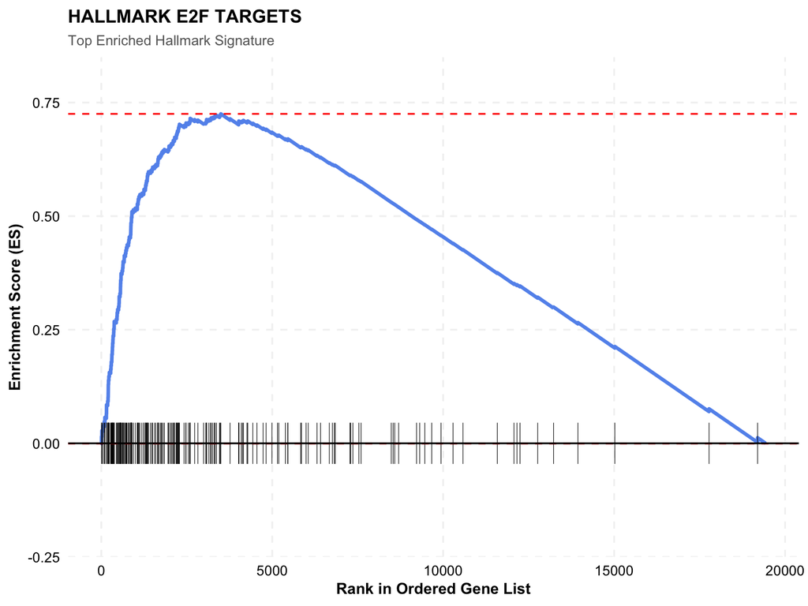

```r
# Plot top enriched pathway
if (nrow(fgsea_H[fgsea_H$ES > 0, ]) > 0) {
  top_pathway_H <- fgsea_H |>
    filter(ES > 0) |>
    arrange(padj, desc(ES)) |>
    head(1) |>
    pull(pathway)

  p_H <- plotEnrichment(split_genes_H[[top_pathway_H]], ranked_genes)
  p_H$layers[[1]]$aes_params$colour <- "cornflowerblue"
  p_H$layers[[1]]$aes_params$linewidth <- 1.2

  p_H <- p_H +
    labs(
      title = gsub("_", " ", top_pathway_H),
      subtitle = "Top Enriched Hallmark Signature",
      x = "Rank in Ordered Gene List",
      y = "Enrichment Score (ES)"
    ) +
    coord_cartesian(ylim = c(-0.2, 0.8)) +
    theme_minimal(base_size = 13) +
    theme(
      plot.title = element_text(face = "bold", size = 13, hjust = 0),
      plot.subtitle = element_text(size = 10, color = "grey40", hjust = 0),
      panel.grid.minor = element_blank(),
      panel.grid.major = element_line(color = "grey95", linetype = "dashed"),
      axis.title = element_text(face = "bold", size = 11),
      axis.text = element_text(color = "black", size = 10)
    )
  print(p_H)
}
```

These pathways indicate, that patients that respond to anti-PD-L1 treatment have a higher expression of genes involved in immune response (inteferon gamma and alpha), and cell proliferation (E2F targets and G2M).

Similarly, pathways that are downregulated, would normally control cell division. Interestingly, two of the downregulated pathways are involved with blood vessels and clotting (angiogenesis and coagulation).

```r
# C7 pathways
topPathwaysUp_C7 <- fgsea_C7[ES > 0][head(order(pval), n = number_of_top_pathways_up), pathway]
topPathwaysDown_C7 <- fgsea_C7[ES < 0][head(order(pval), n = number_of_top_pathways_down), pathway]
topPathways_C7 <- c(topPathwaysUp_C7, rev(topPathwaysDown_C7))

# Display pathway enrichment table
if (interactive()) {
  plotGseaTable(split_genes_C7[topPathways_C7],
                stats = ranked_genes,
                fgseaRes = fgsea_C7,
                gseaParam = 0.5)
}

# Get top pathways tables
top_pathways_C7 <- fgsea_C7 |>
  dplyr::arrange(padj) |>
  dplyr::slice(1:20)

kable(top_pathways_C7 |> select(pathway, NES, padj),
      caption = 'Top 20 C7 immune signature pathways')
```

Top 20 C7 immune signature pathways

| pathway | NES | padj |
| --- | --- | --- |
| GSE15750_DAY6_VS_DAY10_EFF_CD8_TCELL_UP | 3.738823 | 5.215000e-47 |
| GSE15750_DAY6_VS_DAY10_TRAF6KO_EFF_CD8_TCELL_UP | 3.524098 | 2.733326e-39 |
| GSE13547_CTRL_VS_ANTI_IGM_STIM_BCELL_12H_UP | 3.461753 | 1.796221e-36 |
| GSE14415_INDUCED_TREG_VS_TCONV_UP | 3.393398 | 2.982174e-32 |
| GSE24634_TEFF_VS_TCONV_DAY7_IN_CULTURE_UP | 3.271570 | 1.332670e-30 |
| GSE13547_2H_VS_12_H_ANTI_IGM_STIM_BCELL_DN | 3.293188 | 1.351155e-30 |
| GSE39556_CD8A_DC_VS_NK_CELL_MOUSE_3H_POST_POLYIC_INJ_UP | 3.274301 | 1.896723e-30 |
| GSE30962_PRIMARY_VS_SECONDARY_ACUTE_LCMV_INF_CD8_TCELL_UP | 3.230886 | 5.125768e-30 |
| GSE21063_WT_VS_NFATC1_KO_8H_ANTI_IGM_STIM_BCELL_UP | 3.249085 | 1.733856e-28 |
| HOWARD_NK_CELL_INACT_MONOV_INFLUENZA_A_INDONESIA_05_2005_H5N1_AGE_18_49YO_3DY_UP | 3.597660 | 2.139280e-28 |
| GSE36476_CTRL_VS_TSST_ACT_72H_MEMORY_CD4_TCELL_OLD_DN | 3.172504 | 4.762072e-28 |
| GSE13547_CTRL_VS_ANTI_IGM_STIM_BCELL_2H_UP | 3.217262 | 2.336012e-27 |
| GSE14415_NATURAL_TREG_VS_TCONV_DN | 3.205832 | 5.740518e-27 |
| GSE18893_TCONV_VS_TREG_24H_TNF_STIM_UP | 3.154080 | 1.502453e-26 |
| GSE37532_WT_VS_PPARG_KO_VISCERAL_ADIPOSE_TISSUE_TREG_UP | 3.147224 | 6.276533e-26 |
| GSE5679_CTRL_VS_PPARG_LIGAND_ROSIGLITAZONE_TREATED_DC_UP | 3.129985 | 1.022755e-25 |
| GSE36476_CTRL_VS_TSST_ACT_40H_MEMORY_CD4_TCELL_OLD_DN | 3.067319 | 1.682184e-25 |
| GSE36476_CTRL_VS_TSST_ACT_72H_MEMORY_CD4_TCELL_YOUNG_DN | 3.078845 | 2.379335e-25 |
| GSE14415_TCONV_VS_FOXP3_KO_INDUCED_TREG_DN | 3.130256 | 5.308324e-25 |
| GSE37533_PPARG1_FOXP3_VS_FOXP3_TRANSDUCED_CD4_TCELL_DN | 3.016955 | 2.372496e-24 |

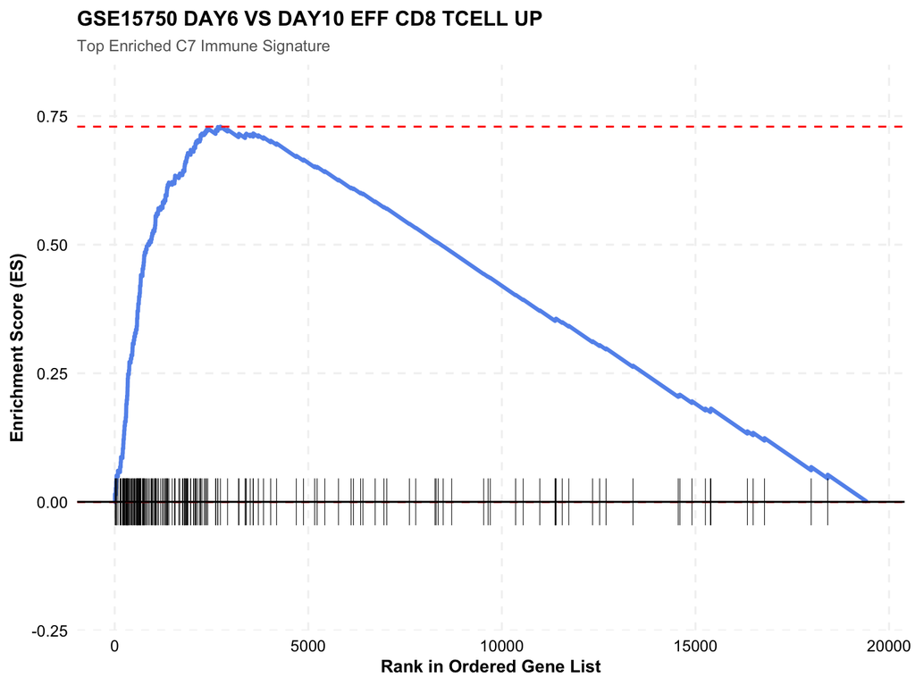

```r
# Plot top enriched pathways
if (nrow(fgsea_C7[fgsea_C7$ES > 0, ]) > 0) {
  top_pathway_C7_up <- fgsea_C7 |>
    filter(ES > 0) |>
    arrange(padj, desc(ES)) |>
    head(1) |>
    pull(pathway)

  p_C7_up <- plotEnrichment(split_genes_C7[[top_pathway_C7_up]], ranked_genes)
  p_C7_up$layers[[1]]$aes_params$colour <- "cornflowerblue"
  p_C7_up$layers[[1]]$aes_params$linewidth <- 1.2

  p_C7_up <- p_C7_up +
    labs(
      title = gsub("_", " ", top_pathway_C7_up),
      subtitle = "Top Enriched C7 Immune Signature",
      x = "Rank in Ordered Gene List",
      y = "Enrichment Score (ES)"
    ) +
    coord_cartesian(ylim = c(-0.2, 0.8)) +
    theme_minimal(base_size = 13) +
    theme(
      plot.title = element_text(face = "bold", size = 13, hjust = 0),
      plot.subtitle = element_text(size = 10, color = "grey40", hjust = 0),
      panel.grid.minor = element_blank(),
      panel.grid.major = element_line(color = "grey95", linetype = "dashed"),
      axis.title = element_text(face = "bold", size = 11),
      axis.text = element_text(color = "black", size = 10)
    )
  print(p_C7_up)
}
```

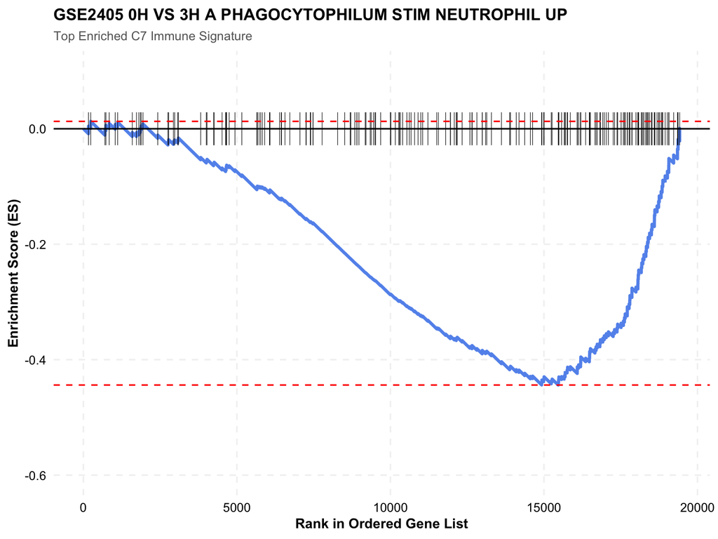

```r
if (nrow(fgsea_C7[fgsea_C7$ES < 0, ]) > 0) {
  top_pathway_C7_down <- fgsea_C7 |>
    filter(ES < 0) |>
    arrange(padj, ES) |>
    head(1) |>
    pull(pathway)

  p_C7_down <- plotEnrichment(split_genes_C7[[top_pathway_C7_down]], ranked_genes)
  p_C7_down$layers[[1]]$aes_params$colour <- "cornflowerblue"
  p_C7_down$layers[[1]]$aes_params$linewidth <- 1.2

  p_C7_down <- p_C7_down +
    labs(
      title = gsub("_", " ", top_pathway_C7_down),
      subtitle = "Top Enriched C7 Immune Signature",
      x = "Rank in Ordered Gene List",
      y = "Enrichment Score (ES)"
    ) +
    coord_cartesian(ylim = c(-0.6, 0.1)) +
    theme_minimal(base_size = 13) +
    theme(
      plot.title = element_text(face = "bold", size = 13, hjust = 0),
      plot.subtitle = element_text(size = 10, color = "grey40", hjust = 0),
      panel.grid.minor = element_blank(),
      panel.grid.major = element_line(color = "grey95", linetype = "dashed"),
      axis.title = element_text(face = "bold", size = 11),
      axis.text = element_text(color = "black", size = 10)
    )
  print(p_C7_down)
}
```

The upregulated pathways here are showing signs of active CD8+ T cell responses, as weel as other T-cells and long B-cell response.

```r
# C8 pathways
topPathwaysUp_C8 <- fgsea_C8[ES > 0][head(order(pval), n = number_of_top_pathways_up), pathway]
topPathwaysDown_C8 <- fgsea_C8[ES < 0][head(order(pval), n = number_of_top_pathways_down), pathway]
topPathways_C8 <- c(topPathwaysUp_C8, rev(topPathwaysDown_C8))

# Display pathway enrichment table
if (interactive()) {
  plotGseaTable(split_genes_C8[topPathways_C8],
                stats = ranked_genes,
                fgseaRes = fgsea_C8,
                gseaParam = 0.5)
}

# Multiple pathways have the same very very low p-value, so we will display the pathways with the minimal p-value for both upregulated and downregulated pathways.
if (nrow(fgsea_C8[fgsea_C8$ES > 0 & fgsea_C8$padj == min(fgsea_C8$padj[fgsea_C8$ES > 0]), ]) > 0) {
  kable(fgsea_C8 |>
    as.data.frame() |>
    filter(ES > 0) |>
    filter(padj == min(padj)) |>
    select(pathway, NES, padj),
    caption = 'Pathways with minimal p-value (upregulated)')
}
```

Pathways with minimal p-value (upregulated)

| pathway | NES | padj |
| --- | --- | --- |
| FAN_EMBRYONIC_CTX_MICROGLIA_1 | 3.875493 | 7.9e-49 |
| FAN_EMBRYONIC_CTX_NSC_2 | 3.716086 | 7.9e-49 |
| HAY_BONE_MARROW_ERYTHROBLAST | 2.687354 | 7.9e-49 |
| HE_LIM_SUN_FETAL_LUNG_C2_CYCLING_DC_CELL | 3.224684 | 7.9e-49 |
| HE_LIM_SUN_FETAL_LUNG_C2_PROMONOCYTE_LIKE_CELL | 3.705846 | 7.9e-49 |
| HE_LIM_SUN_FETAL_LUNG_C4_CYCLING_NK_CELL | 3.744358 | 7.9e-49 |
| HE_LIM_SUN_FETAL_LUNG_C4_CYCLING_T_CELL | 3.387735 | 7.9e-49 |
| HE_LIM_SUN_FETAL_LUNG_C5_LARGE_PRE_B_CELL | 3.491446 | 7.9e-49 |
| HE_LIM_SUN_FETAL_LUNG_C5_PRO_B_CELL | 3.523849 | 7.9e-49 |
| SU_HO_FOETAL_FEMUR_C3_PROLIFERATING_CHONDROCYTE | 3.579902 | 7.9e-49 |
| ZHONG_PFC_C1_OPC | 3.756642 | 7.9e-49 |

```r
# Get top pathways tables
top_pathways_C8 <- fgsea_C8 |>
  dplyr::arrange(padj) |>
  dplyr::slice(1:20)

kable(top_pathways_C8 |> select(pathway, NES, padj),
      caption = 'Top 20 C8 cell-type signature pathways')
```

Top 20 C8 cell-type signature pathways

| pathway | NES | padj |
| --- | --- | --- |
| FAN_EMBRYONIC_CTX_MICROGLIA_1 | 3.875493 | 7.900000e-49 |
| FAN_EMBRYONIC_CTX_NSC_2 | 3.716086 | 7.900000e-49 |
| HAY_BONE_MARROW_ERYTHROBLAST | 2.687354 | 7.900000e-49 |
| HE_LIM_SUN_FETAL_LUNG_C2_CYCLING_DC_CELL | 3.224684 | 7.900000e-49 |
| HE_LIM_SUN_FETAL_LUNG_C2_PROMONOCYTE_LIKE_CELL | 3.705846 | 7.900000e-49 |
| HE_LIM_SUN_FETAL_LUNG_C4_CYCLING_NK_CELL | 3.744358 | 7.900000e-49 |
| HE_LIM_SUN_FETAL_LUNG_C4_CYCLING_T_CELL | 3.387735 | 7.900000e-49 |
| HE_LIM_SUN_FETAL_LUNG_C5_LARGE_PRE_B_CELL | 3.491446 | 7.900000e-49 |
| HE_LIM_SUN_FETAL_LUNG_C5_PRO_B_CELL | 3.523849 | 7.900000e-49 |
| SU_HO_FOETAL_FEMUR_C3_PROLIFERATING_CHONDROCYTE | 3.579902 | 7.900000e-49 |
| ZHONG_PFC_C1_OPC | 3.756642 | 7.900000e-49 |
| HE_LIM_SUN_FETAL_LUNG_C3_CYCLING_DEFINITIVE_ERYTHROBLAST | 3.204150 | 7.241000e-47 |
| TRAVAGLINI_LUNG_PROLIFERATING_BASAL_CELL | 2.606374 | 1.903290e-45 |
| HAY_BONE_MARROW_PRO_B | 3.363182 | 2.479246e-44 |
| SU_HO_CONV_CENT_CHONDROSARCOMA_C7_PROLIFERATIVE | 3.494207 | 9.231027e-44 |
| TRAVAGLINI_LUNG_PROLIFERATING_MACROPHAGE_CELL | 2.495846 | 9.253855e-44 |
| DESCARTES_FETAL_LIVER_HEPATOBLASTS | -2.858187 | 2.695065e-41 |
| HE_LIM_SUN_FETAL_LUNG_C1_EARLY_STALK_CELL | 2.829712 | 4.203120e-39 |
| TRAVAGLINI_LUNG_PROLIFERATING_NK_T_CELL | 3.643061 | 5.037263e-38 |
| HAY_BONE_MARROW_STROMAL | -2.465164 | 4.436972e-37 |

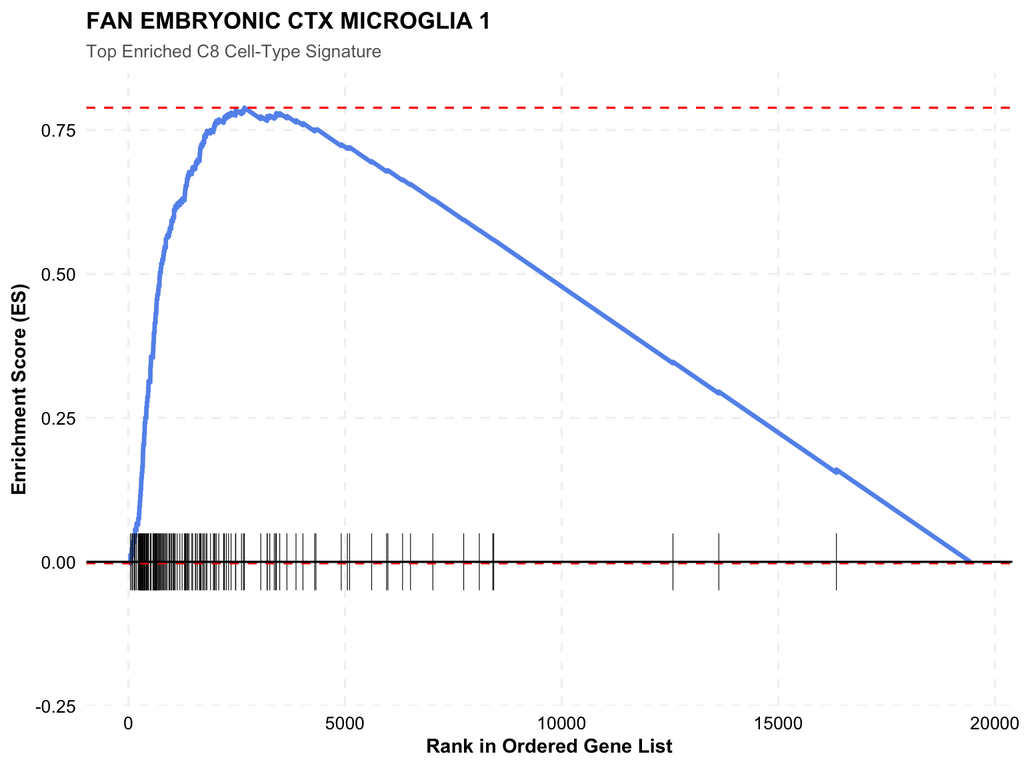

```r
# Plot top enriched pathways
if (nrow(fgsea_C8[fgsea_C8$ES > 0, ]) > 0) {
  top_pathway_C8_up <- fgsea_C8 |>
    filter(ES > 0) |>
    arrange(padj, desc(ES)) |>
    head(1) |>
    pull(pathway)

  p_C8_up <- plotEnrichment(split_genes_C8[[top_pathway_C8_up]], ranked_genes)
  p_C8_up$layers[[1]]$aes_params$colour <- "cornflowerblue"
  p_C8_up$layers[[1]]$aes_params$linewidth <- 1.2

  p_C8_up <- p_C8_up +
    labs(
      title = gsub("_", " ", top_pathway_C8_up),
      subtitle = "Top Enriched C8 Cell-Type Signature",
      x = "Rank in Ordered Gene List",
      y = "Enrichment Score (ES)"
    ) +
    coord_cartesian(ylim = c(-0.2, 0.8)) +
    theme_minimal(base_size = 13) +
    theme(
      plot.title = element_text(face = "bold", size = 13, hjust = 0),
      plot.subtitle = element_text(size = 10, color = "grey40", hjust = 0),
      panel.grid.minor = element_blank(),
      panel.grid.major = element_line(color = "grey95", linetype = "dashed"),
      axis.title = element_text(face = "bold", size = 11),
      axis.text = element_text(color = "black", size = 10)
    )
  print(p_C8_up)
}
```

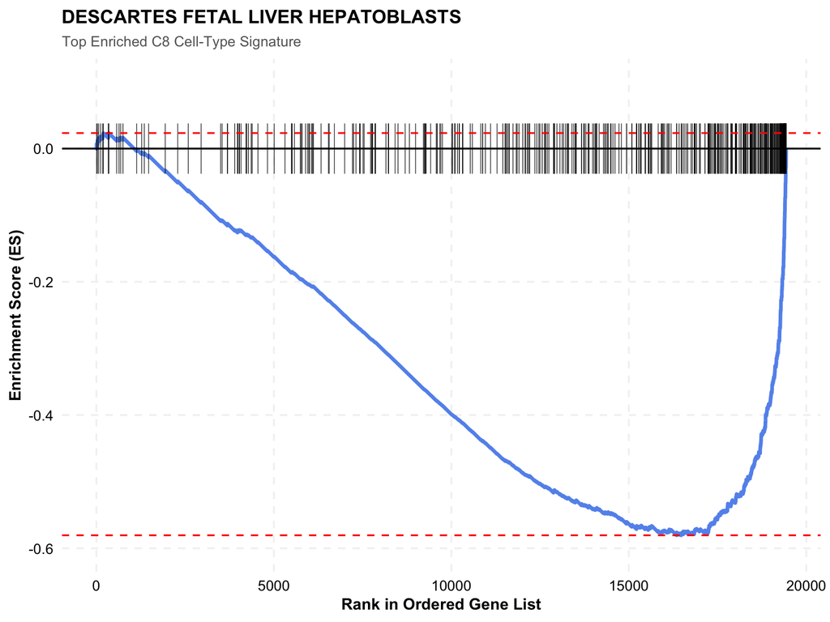

```r
if (nrow(fgsea_C8[fgsea_C8$ES < 0, ]) > 0) {
  top_pathway_C8_down <- fgsea_C8 |>
    filter(ES < 0) |>
    arrange(padj, ES) |>
    head(1) |>
    pull(pathway)

  p_C8_down <- plotEnrichment(split_genes_C8[[top_pathway_C8_down]], ranked_genes)
  p_C8_down$layers[[1]]$aes_params$colour <- "cornflowerblue"
  p_C8_down$layers[[1]]$aes_params$linewidth <- 1.2

  p_C8_down <- p_C8_down +
    labs(
      title = gsub("_", " ", top_pathway_C8_down),
      subtitle = "Top Enriched C8 Cell-Type Signature",
      x = "Rank in Ordered Gene List",
      y = "Enrichment Score (ES)"
    ) +
    coord_cartesian(ylim = c(-0.6, 0.1)) +
    theme_minimal(base_size = 13) +
    theme(
      plot.title = element_text(face = "bold", size = 13, hjust = 0),
      plot.subtitle = element_text(size = 10, color = "grey40", hjust = 0),
      panel.grid.minor = element_blank(),
      panel.grid.major = element_line(color = "grey95", linetype = "dashed"),
      axis.title = element_text(face = "bold", size = 11),
      axis.text = element_text(color = "black", size = 10)
    )
  print(p_C8_down)
}
```

### Discussion - RQ1 Limitations

Differential expression analysis identifies genes associated with treatment response, but has several limitations:

1. **Correlation ≠ Causation:** Differentially expressed genes may be passengers rather than drivers of response
2. **Confounding factors:** Tumor purity, batch effects, and other technical/biological factors may influence results
3. **Multiple testing:** While we control FDR, some false positives may remain
4. **Bulk RNA-seq:** Cannot distinguish between tumor and immune cell expression
5. **Heterogeneity:** Patient-specific factors may contribute to variability

The GSEA results provide biological context, showing that immune-related pathways are enriched among differentially expressed genes, which aligns with the mechanism of action of PD-L1 inhibitors.

#### Biological interpretation

Given the above results, we can see that the differentially expressed genes and enriched pathways suggest that patients who respond to anti-PD-L1 treatment have a more active and long-term immune response. The upregulated pathways indicate increased activity of CD8+ T cells, other T cells, and B cells, while the downregulated pathways suggest a reduced short-term innate immune response. This could imply that a robust adaptive immune response is associated with better treatment outcomes.

#### Limitations and discussion

As the data comes from bulk RNA expression, some of the samples could have low tumor purity, leading to results coming from low tumor expression due to high immune infiltration. This could be a confounding factor, as the immune response could be driving the observed differences in gene expression rather than the tumor cells themselves.

## Research Question 2: Immune-Related Signatures

**Question:** Are 18-gene T-cell-inflamed GEP (Ayers et al. 2017) associated with treatment response?

Reference: Ayers et al. (2017). JCI. https://doi.org/10.1172/JCI91190

### Methods

- Identify the 18 genes included in the published T-cell-inflamed GEP
- Calculate a GEP score for each patient (mean of standardized expression)
- Investigate association between GEP scores and treatment response
- Interpret biological significance

### Calculate T-cell-inflamed GEP Scores

```r
# Define the 18 GEP genes from Ayers et al. (2017)
GEP_genes <- c(
  "CD27", "CD274", "CCL5",
  "CD276", "CD8A", "CMKLR1",
  "CXCL9", "CXCR6", "HLA-DQA1",
  "HLA-DRB1", "HLA-E", "IDO1",
  "LAG3", "NKG7", "PDCD1LG2",
  "PSMB10", "STAT1", "TIGIT"
)

# Check which genes are present in the dataset
gene_list <- rownames(counts_matrix)
GEP_genes_present <- GEP_genes[GEP_genes %in% gene_list]
GEP_genes_missing <- setdiff(GEP_genes, gene_list)

kable(data.frame(
  Check = c("GEP genes present", "Missing GEP genes"),
  Value = c(paste(length(GEP_genes_present), "of", length(GEP_genes)),
            if (length(GEP_genes_missing) > 0) paste(GEP_genes_missing, collapse = ", ") else "none")
))
```

| Check | Value |
| --- | --- |
| GEP genes present | 18 of 18 |
| Missing GEP genes | none |

```r
# Standardize each gene across samples and calculate mean
clinical_filtered$GEP_scores <- colMeans(t(scale(t(tpm_matrix[GEP_genes_present, , drop = FALSE]))), na.rm = TRUE)

kable(t(as.matrix(summary(clinical_filtered$GEP_scores))), row.names = FALSE)
```

| Min. | 1st Qu. | Median | Mean | 3rd Qu. | Max. |
| --- | --- | --- | --- | --- | --- |
| -0.8383448 | -0.4758281 | -0.1284904 | -1.029269e-16 | 0.2238813 | 2.452981 |

### Association with Response

```r
# Wilcoxon test for GEP vs Response
GEP_Response_test <- wilcox.test(GEP_scores ~ BOR, data = clinical_filtered)

kable(broom::tidy(GEP_Response_test))
```

| statistic | p.value | method | alternative |
| --- | --- | --- | --- |
| 1106 | 0.0001532414 | Wilcoxon rank sum test with continuity correction | two.sided |

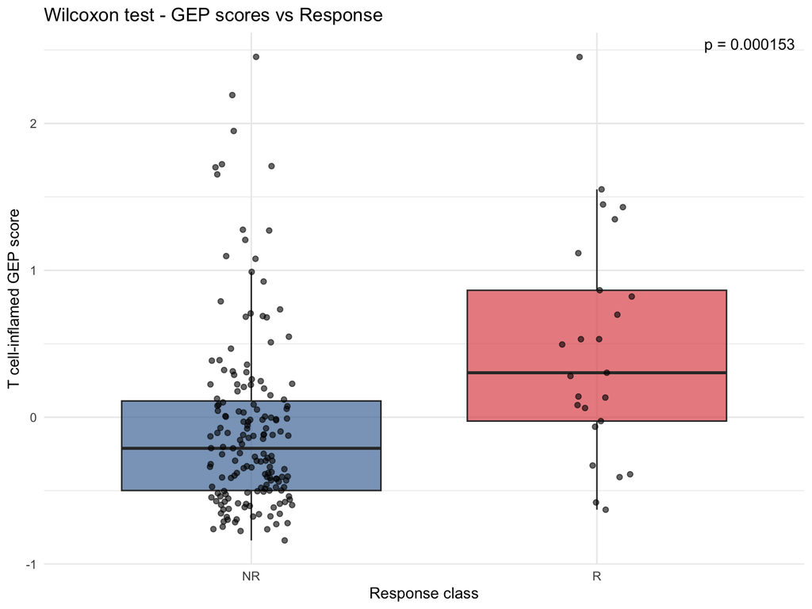

```r
# Boxplot
plot_response_boxplot(
  clinical_filtered,
  "GEP_scores",
  "T cell-inflamed GEP score",
  GEP_Response_test,
  label_outliers = FALSE
) +
labs(title = "Wilcoxon test - GEP scores vs Response")
```

### Biological Interpretation - RQ2

The T-cell-inflamed GEP measures the expression of genes involved in T-cell infiltration and activation within the tumor microenvironment. A high GEP score indicates a “hot” tumor with active immune infiltration, which is more likely to respond to immune checkpoint inhibitors.

## Research Question 3: Biomarker Comparison

**Question:** How do PD-1 (PDCD1) expression, immune-related gene signatures, and tumor mutational burden (TMB) compare in their association with different treatment responses?

### Methods

- Extract PD-1 expression, GEP scores, and TMB
- Visualize distributions using boxplots
- Perform statistical tests (Wilcoxon)
- Compare effect sizes and significance
- Discuss biological information captured by each biomarker

### Extract Biomarkers

```r
# Extract PD-1 expression from TPM
clinical_filtered$PD1 <- as.numeric(tpm_matrix["PDCD1", ])

# Check for missing TMB values and handle them
clinical_filtered$TMB <- ifelse(is.na(clinical_filtered$TMB), median(clinical_filtered$TMB, na.rm = TRUE), clinical_filtered$TMB)

kable(summary(clinical_filtered |> select(TMB, PD1, GEP_scores)),
      caption = "Summary of Biomarkers")
```

Summary of Biomarkers

| TMB | PD1 | GEP_scores |
| --- | --- | --- |
| Min. : 0.000 | Min. :0.0000 | Min. :-0.8383 |
| 1st Qu.: 5.000 | 1st Qu.:0.2060 | 1st Qu.:-0.4758 |
| Median : 7.000 | Median :0.5947 | Median :-0.1285 |
| Mean : 9.531 | Mean :0.9429 | Mean : 0.0000 |
| 3rd Qu.:12.000 | 3rd Qu.:1.2885 | 3rd Qu.: 0.2239 |
| Max. :62.000 | Max. :5.3441 | Max. : 2.4530 |

### Compare Biomarker Distributions

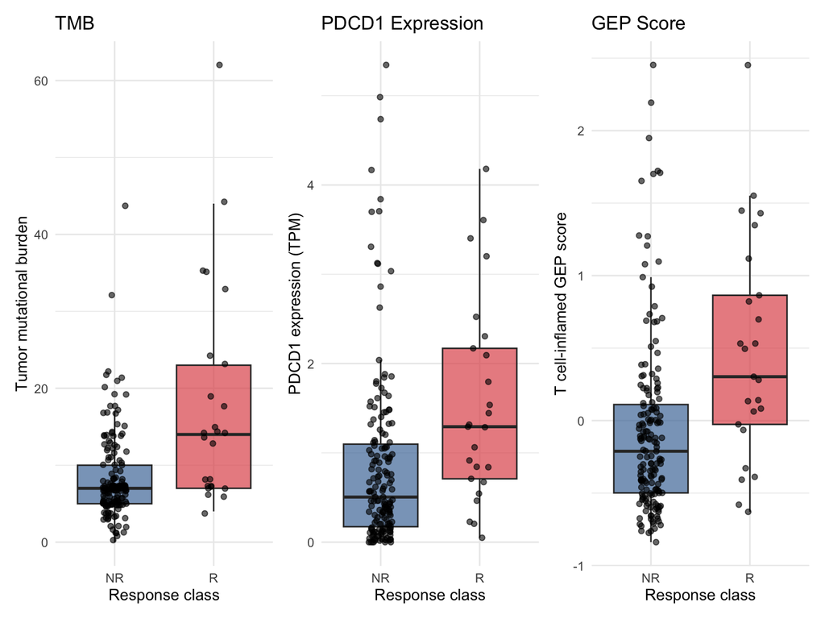

```r
# Create individual boxplots
p_tmb <- plot_response_boxplot(clinical_filtered, "TMB", "Tumor mutational burden") +
  ggtitle("TMB")

p_pd1 <- plot_response_boxplot(clinical_filtered, "PD1", "PDCD1 expression (TPM)") +
  ggtitle("PDCD1 Expression")

p_gep <- plot_response_boxplot(clinical_filtered, "GEP_scores", "T cell-inflamed GEP score") +
  ggtitle("GEP Score")

(p_tmb + p_pd1 + p_gep) + plot_layout(ncol = 3)
```

### Statistical Tests

```r
# Wilcoxon tests
TMB_Response_test <- wilcox.test(TMB ~ BOR, data = clinical_filtered)
PD1_Response_test <- wilcox.test(PD1 ~ BOR, data = clinical_filtered)
GEP_Response_test <- wilcox.test(GEP_scores ~ BOR, data = clinical_filtered)

kable(dplyr::bind_rows(
  TMB = broom::tidy(TMB_Response_test),
  PD1 = broom::tidy(PD1_Response_test),
  GEP = broom::tidy(GEP_Response_test),
  .id = "Marker"
) |> dplyr::mutate(p.value = signif(p.value, 3)))
```

| Marker | statistic | p.value | method | alternative |
| --- | --- | --- | --- | --- |
| TMB | 1013.5 | 2.71e-05 | Wilcoxon rank sum test with continuity correction | two.sided |
| PD1 | 1169.0 | 3.96e-04 | Wilcoxon rank sum test with continuity correction | two.sided |
| GEP | 1106.0 | 1.53e-04 | Wilcoxon rank sum test with continuity correction | two.sided |

```r
# Calculate Spearman correlations
clinical_filtered$Response_num <- as.numeric(clinical_filtered$BOR == "R")

PD1_cor <- cor.test(clinical_filtered$PD1, clinical_filtered$Response_num, method = "spearman",
                        exact = FALSE, use = "complete.obs")
TMB_cor <- cor.test(clinical_filtered$TMB, clinical_filtered$Response_num, method = "spearman",
                        exact = FALSE, use = "complete.obs")
GEP_cor <- cor.test(clinical_filtered$GEP_scores, clinical_filtered$Response_num, method = "spearman",
                        exact = FALSE, use = "complete.obs")

kable(data.frame(
  Comparison = c("PD1", "TMB", "GEP"),
  rho = round(c(PD1_cor$estimate,
                TMB_cor$estimate,
                GEP_cor$estimate), 3),
  p.value = signif(c(PD1_cor$p.value,
                     TMB_cor$p.value,
                     GEP_cor$p.value), 3)
))
```

| Comparison | rho | p.value |
| --- | --- | --- |
| PD1 | 0.256 | 3.29e-04 |
| TMB | 0.304 | 1.84e-05 |
| GEP | 0.274 | 1.20e-04 |

### Discussion - RQ3

**Do the biomarkers differ between response groups?**

Because the biomarkers are not normally distributed and the groups are unbalanced (25 R vs 167 NR), we used the Wilcoxon rank-sum test. All three biomarkers differed significantly between responders and non-responders.

**Which biomarker is most strongly associated with response?**

All three biomarkers were higher in responders. Spearman correlation with response showed that TMB had the strongest association (rho = 0.30), followed by the GEP (rho = 0.27) and PD-1 (rho = 0.26). The groups overlap considerably, so no single biomarker separates responders from non-responders well.

**What does each biomarker capture?**

| Biomarker | Biological information | Strengths | Limitations |
| --- | --- | --- | --- |
| **TMB** | Number of mutations in the tumour; a higher TMB may lead to more neoantigens that T cells can recognise | Associated with better immunotherapy response in several cancer types; already used clinically | Not all mutations create immunogenic neoantigens, does not reflect immune activity; requires DNA sequencing |
| **PD-1 (PDCD1)** | Marker of T-cell activation and exhaustion; high expression indicates T cells are present but may be suppressed | Directly related to the mechanism of action (checkpoint blockade of the PD-1/PD-L1 axis releases this suppression) | Single marker; can also be expressed on other immune cells |
| **T cell-inflamed GEP** | Broader immune activation signature including checkpoint molecules, chemokines and MHC genes | More robust than single-gene markers; better captures the overall immune landscape | More complex to compute; reflects immune presence, not whether T cells reach the tumour |

## Research Question 4: Tumor Purity Analysis

**Question:** How might differences in tumor purity influence the expression of immune-related biomarkers and their observed associations with treatment response?

### Methods

- Estimate tumor purity using ESTIMATE algorithm via `immunedeconv` package
- Analyze relationship between tumor purity and each biomarker (PD-1, GEP, TMB)
- Adjust expression for tumor purity using `removeBatchEffect()` from `limma`
- Re-evaluate biomarker-response associations after purity adjustment
- Discuss whether purity adjustment improves interpretation

### Background

Bulk tumor RNA-seq contains RNA from:

- Malignant tumor cells
- Immune cells (lymphocytes, macrophages, etc.)
- Stromal cells (fibroblasts, endothelial cells, etc.)

**Tumor purity** refers to the proportion of tumor cells in the sample. Variation in tumor purity can influence biomarker measurements: - **Immune biomarkers** (PD-1, GEP) are expected to be **negatively** correlated with tumor purity (higher in samples with more immune cells) - **TMB** may be **positively** correlated with tumor purity (more tumor cells = more mutations detected)

### Estimate Tumor Purity

```r
# Estimate tumor purity using ESTIMATE
suppressMessages({
  purity <- deconvolute_estimate(tpm_matrix)
})
```

```
[1] "Merged dataset includes 10236 genes (176 mismatched)."
[1] "1 gene set: StromalSignature  overlap= 139"
[1] "2 gene set: ImmuneSignature  overlap= 141"
```

```r
kable(data.frame(
  Check = c("Dimensions", "Row names"),
  Value = c(paste(dim(purity), collapse = " x "),
            paste(rownames(purity), collapse = ", "))
),
caption = "ESTIMATE output summary"
)
```

ESTIMATE output summary

| Check | Value |
| --- | --- |
| Dimensions | 4 x 192 |
| Row names | StromalScore, ImmuneScore, ESTIMATEScore, TumorPurity |

```r
# Extract tumor purity estimates
tumor_purity <- as.numeric(purity[grep("purity", rownames(purity), ignore.case = TRUE, value = TRUE), ])
names(tumor_purity) <- colnames(purity)

# Reorder to match sample order in df
tumor_purity <- tumor_purity[rownames(clinical_filtered)]

# Add to dataframe
clinical_filtered$purity <- tumor_purity

kable(summary(clinical_filtered |> select(purity)),
      caption = "Summary of estimated tumor purity across samples")
```

Summary of estimated tumor purity across samples

| purity |
| --- |
| Min. :0.2993 |
| 1st Qu.:0.5467 |
| Median :0.6517 |
| Mean :0.6637 |
| 3rd Qu.:0.7803 |
| Max. :0.9593 |

```r
# Also extract immune and stromal scores for completeness
clinical_filtered$ImmuneScore <- as.numeric(purity["ImmuneScore", rownames(clinical_filtered)])
clinical_filtered$StromalScore <- as.numeric(purity["StromalScore", rownames(clinical_filtered)])
clinical_filtered$ESTIMATEScore <- as.numeric(purity["ESTIMATEScore", rownames(clinical_filtered)])
```

```r
Purity_Response_test <- wilcox.test(
  purity ~ BOR,
  data = clinical_filtered
)

print(Purity_Response_test)
```

```
    Wilcoxon rank sum test with continuity correction

data:  purity by BOR
W = 2441, p-value = 0.1731
alternative hypothesis: true location shift is not equal to 0
```

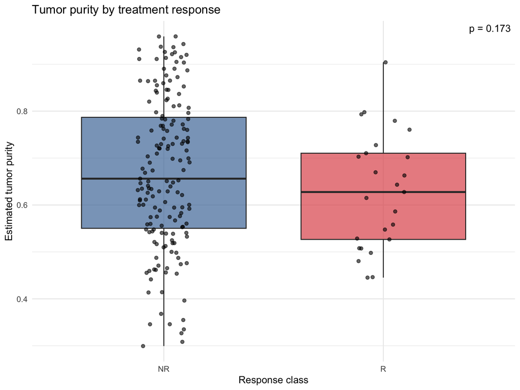

```r
plot_response_boxplot(
  clinical_filtered,
  "purity",
  "Estimated tumor purity",
  Purity_Response_test
) +
  labs(title = "Tumor purity by treatment response")
```

### Purity-Biomarker Associations

```r
# Calculate Spearman correlations between purity and biomarkers
TMB_purity_cor <- cor.test(
  clinical_filtered$purity, clinical_filtered$TMB,
  method = "spearman",
  exact = FALSE,
  use = "complete.obs"
)

PD1_purity_cor <- cor.test(
  clinical_filtered$purity, clinical_filtered$PD1,
  method = "spearman",
  exact = FALSE,
  use = "complete.obs"
)

GEP_purity_cor <- cor.test(
  clinical_filtered$purity, clinical_filtered$GEP_scores,
  method = "spearman",
  exact = FALSE,
  use = "complete.obs"
)

kable(data.frame(
  Comparison = c("TMB vs Purity", "PD1 vs Purity", "GEP vs Purity"),
  rho = round(c(TMB_purity_cor$estimate,
                PD1_purity_cor$estimate,
                GEP_purity_cor$estimate), 3),
  p.value = signif(c(TMB_purity_cor$p.value,
                     PD1_purity_cor$p.value,
                     GEP_purity_cor$p.value), 3)
))
```

| Comparison | rho | p.value |
| --- | --- | --- |
| TMB vs Purity | 0.110 | 1.30e-01 |
| PD1 vs Purity | -0.691 | 1.35e-28 |
| GEP vs Purity | -0.761 | 1.70e-37 |

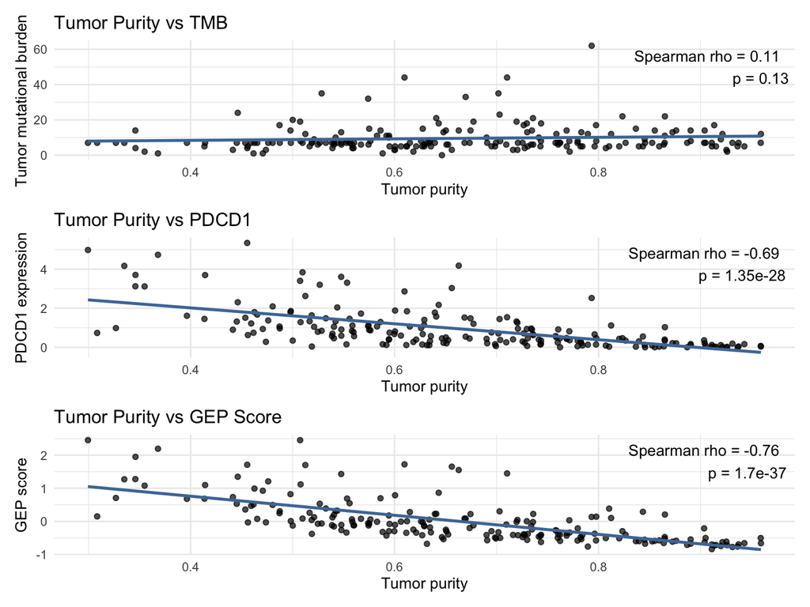

```r
# Create plots
p_tmb_purity <- plot_association(
  clinical_filtered, "purity", "TMB",
  "Tumor purity", "Tumor mutational burden", TMB_purity_cor
) + ggtitle("Tumor Purity vs TMB")

p_pd1_purity <- plot_association(
  clinical_filtered, "purity", "PD1",
  "Tumor purity", "PDCD1 expression", PD1_purity_cor
) + ggtitle("Tumor Purity vs PDCD1")

p_gep_purity <- plot_association(
  clinical_filtered, "purity", "GEP_scores",
  "Tumor purity", "GEP score", GEP_purity_cor
) + ggtitle("Tumor Purity vs GEP Score")

# Display in a grid
(p_tmb_purity + p_pd1_purity + p_gep_purity) + plot_layout(nrow = 3)
```

### Purity-Adjusted Expression Analysis

```r
# Adjust expression matrix for tumor purity
suppressMessages({
  tpm_adjusted <- removeBatchEffect(
    tpm_matrix,
    covariates = matrix(clinical_filtered$purity, ncol = 1)
  )
})

# Recalculate biomarkers from adjusted expression
clinical_adjusted <- data.frame(
  sample = rownames(clinical_filtered),
  TMB = clinical_filtered$TMB,  # TMB doesn't need adjustment as it's not expression-based
  PD1 = as.numeric(tpm_adjusted["PDCD1", ]),
  GEP_scores = colMeans(t(scale(t(tpm_adjusted[GEP_genes_present, , drop = FALSE]))), na.rm = TRUE),
  purity = clinical_filtered$purity,
  BOR = clinical_filtered$BOR,
  stringsAsFactors = FALSE
)

# Verify alignment
stopifnot(identical(clinical_adjusted$sample, rownames(clinical_filtered)))
```

### Re-evaluate Biomarker-Response Associations After Adjustment

```r
# Wilcoxon tests with adjusted biomarkers
PD1_Response_adjusted_test <- wilcox.test(PD1 ~ BOR, data = clinical_adjusted)
GEP_Response_adjusted_test <- wilcox.test(GEP_scores ~ BOR, data = clinical_adjusted)


kable(data.frame(
  Marker = rep(c("PD1", "GEP"), 2),
  Comparison = rep(c("unadjusted", "adjusted"), each = 2),
  p.value = signif(c(PD1_Response_test$p.value,
                     GEP_Response_test$p.value,
                     PD1_Response_adjusted_test$p.value,
                     GEP_Response_adjusted_test$p.value), 3)
))
```

| Marker | Comparison | p.value |
| --- | --- | --- |
| PD1 | unadjusted | 0.000396 |
| GEP | unadjusted | 0.000153 |
| PD1 | adjusted | 0.012800 |
| GEP | adjusted | 0.000486 |

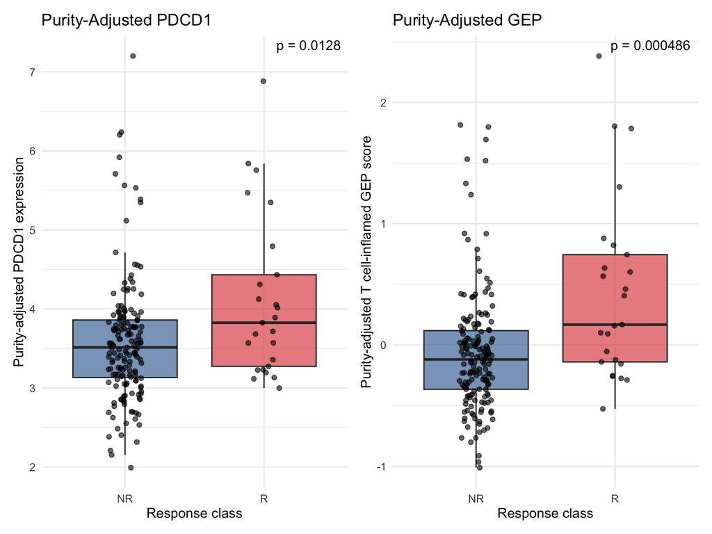

```r
# Boxplots for adjusted biomarkers
p_pd1_adj <- plot_response_boxplot(
  clinical_adjusted, "PD1",
  "Purity-adjusted PDCD1 expression",
  PD1_Response_adjusted_test
) + ggtitle("Purity-Adjusted PDCD1")

p_gep_adj <- plot_response_boxplot(
  clinical_adjusted, "GEP_scores",
  "Purity-adjusted T cell-inflamed GEP score",
  GEP_Response_adjusted_test
) + ggtitle("Purity-Adjusted GEP")

(p_pd1_adj + p_gep_adj) + plot_layout(ncol = 2)
```

### Discussion - RQ4

**How tumor purity influences immune-related biomarkers:**

1. **PD-1 expression:** Strong negative correlation with tumor purity (rho ≈ -0.69, p ≈ 1.35e-28)
   - PD-1 is primarily expressed on immune cells (T-cells)
   - Higher purity = fewer immune cells = lower PD-1 expression
   - This confirms that PD-1 expression in bulk RNA-seq is largely a measure of immune cell content
2. **T-cell-inflamed GEP:** Very strong negative correlation with tumor purity (rho ≈ -0.76, p ≈ 1.70e-37)
   - The GEP includes many immune cell-specific genes
   - Higher purity = fewer immune cells = lower GEP score
   - This is the strongest correlation among the biomarkers
3. **TMB:** Weak positive correlation with tumor purity (rho ≈ 0.11, p ≈ 0.13)
   - TMB is measured from tumor cells
   - Higher purity = more tumor cells = more mutations detected
   - The correlation is weaker and not statisitcally significant (p>0.05)

**Do differences in tumor purity explain the associations observed in RQ2 and RQ3?**

The strong correlations between tumor purity and the immune biomarkers (PD-1 and GEP) suggest that tumor purity is a significant confounder. When we adjust for tumor purity:

- The associations between PD-1/GEP and response **decrease** (p-values increase, all still <0.05)
- This suggests that some of the observed signal was due to differences in tumor purity between responders and non-responders
- However, the associations do not disappear completely, indicating that there is still biology beyond tumor purity

**Should we adjust for tumor purity?**

This is a critical question in precision medicine:

**Arguments FOR adjustment:**

- Removes technical confounding from cellular composition
- Focuses on tumor-intrinsic biology
- May improve predictive accuracy

**Arguments AGAINST adjustment:**

- Immune cell content IS the biology of interest for immunotherapy
- Adjusting for purity removes clinically relevant information
- The immune infiltration (measured by low purity) is part of the treatment mechanism

**Conclusion:** Tumor purity should not be automatically adjusted for. The question is: *What biological question are we asking?*

- If we want to know “Do tumors with certain genetic characteristics respond?” → adjust for purity
- If we want to know “Which patients will respond?” → do NOT adjust, as immune content is predictive

The main lesson is: **Understanding what generates the measured signal is essential before interpreting an association or using a biomarker for patient stratification.**

# Overall Discussion and Conclusion

## Limitations

1. **Sample Size:** The dataset has 192 samples with 167 non-responders and 25 responders. The small number of responders limits statistical power.
2. **Bulk RNA-seq:** Cannot distinguish cell-type specific expression. Single-cell RNA-seq would provide better resolution.
3. **Missing Data:** Some TMB values are missing (42/192), which may introduce bias.
4. **No Survival Data:** The available data does not include PFS or OS, limiting our ability to assess prognostic value.
5. **Technical Variation:** Batch effects and other technical factors may influence results.
6. **Multiple Testing:** While we control FDR for differential expression, we perform many statistical tests throughout the analysis.

## Relevance to Precision Medicine

The findings have several implications for precision medicine:

1. **Biomarker Development:** The T-cell-inflamed GEP appears to be a promising biomarker, but needs validation in larger cohorts and potentially in combination with other markers.
2. **Tumor Purity Consideration:** Tumor purity should be measured and reported alongside any expression-based biomarkers to aid interpretation.
3. **Combination Strategies:** No single biomarker perfectly predicts response. Future work should explore combinations of TMB, PD-1, GEP, and other immune markers.
4. **Mechanistic Insights:** The strong negative correlation between GEP scores and tumor purity suggests that immune-excluded tumors (high purity, low immune infiltration) may be less responsive to immunotherapy, consistent with the findings of Mariathasan et al. (2018).
5. **Clinical Translation:** For clinical application, biomarkers should be:
   - Robust across platforms and batches
   - Biologically interpretable
   - Clinically actionable
   - Validated in prospective studies

## Future Directions

1. **External Validation:** Validate findings in independent cohorts
2. **Single-cell Analysis:** Use single-cell RNA-seq to deconvolute cell-type specific expression
3. **Integrative Models:** Develop multivariate models combining multiple biomarkers
4. **Functional Validation:** Experimentally validate the role of top candidate genes
5. **Longitudinal Analysis:** Analyze pre- and post-treatment samples to understand dynamics
6. **Combination Therapies:** Explore whether non-responders might benefit from combination therapies targeting additional pathways (e.g., TGFβ inhibitors for immune-excluded tumors)

# References

- Ayers, M., et al. (2017). IFN-γ-related mRNA profile predicts clinical response to PD-1 blockade. Journal of Clinical Investigation, 127(8), 2930-2940. https://doi.org/10.1172/JCI91190
- Mariathasan, S., et al. (2018). TGFβ attenuates tumour response to PD-L1 blockade by contributing to exclusion of T cells. Nature, 554(7693), 544-548. https://doi.org/10.1038/nature25501

# AI declaration

Assistance from Large Language Models, specifically with code, formatting and language, was used to improve the clarity and visual presentation of this project. We take responsibility for the scientific content and interpretation of the results.